# Gumi Analysis

Richard Wu

Sunday, February 01, 2015

## 1.背景描述

- 客户的问题是什么？（业务上的）
- 客户希望将这个业务上的问题解决到什么程度？（量化指标）
- 从数据挖掘的角度将这个问题解决到什么程度？（量化指标）
- 达成项目目标的风险在哪里？
- 对于关键的指标客户是如何定义的
- 将业务问题转化成了哪些数据挖掘问题？

```r
# read the data
df <- read.csv("../data/1_combinedData.csv")
```

## 2.数据理解

对于每一个指标

- 缺失情况是什么样的？
- 分布情况是什么样的？

对于重点有关系的指标

- 指标与结果有没有显著关系

若不能通过，则需要思考

- 现有数据是否能支撑业务的商业目标
- 数据分析的目标是否正确
- 解决问题的思路是否正确

**粗略地检查一下各个指标的数据质量**

```r
missingField <- which(sapply(df , MissingPer <- function(x){sum(is.na(x)) / length(x)}) > .5)

# TODO: EXAM THE MISSING VALUE VARIABLE
# stip the missingField
df <- df[ , -missingField]

factorField <- which(sapply(df , is.factor))

# strip the id field
factorField <- factorField[-1]

# strip too many levels factor variable
factorFieldTooManyLevels <- which(sapply(df ,
                                         getTooManyLevelsVar <- function(x) { length(levels(x)) > 20 }))
factorField <- factorField[!names(factorField) %in% names(factorFieldTooManyLevels)]
factorField <- setdiff(factorField , factorFieldTooManyLevels)
# TODO: DEAL WITH THE TOO MANY LEVELS VARIABLE

#general check the factor variable
sapply(df[,factorField] , genContegencyTable <- function(x , y){ table(x , y)} , df$result)
```

```
## $UserStatus
##      y
## x         0     1
##   100 76702 82537
##   101     3     0
##   103    38     0
##   104   163     0
##   109   345     0
##   111  1678     0
##   112   152     0
##
## $Warn5Flag
##    y
## x       0     1
##   0 76693 82537
##   1  2388     0
##
## $UserDelete
##    y
## x       0     1
##   0 78951 82537
##   2   114     0
##   3    16     0
##
## $OaFlag
##    y
## x       0     1
##   0 79080 82535
##   1     1     2
##
## $GenderId
##    y
## x       0     1
##   1 44690 50688
##   2 32151 28759
##   9  2240  3090
##
## $RegistedId
##    y
## x       0     1
```

[output cut: 152 more lines]

```
##   50_B      2     0
##   50_N      1     0
##   8_N      15     2
##
## $IphoneFlag
##    y
## x       0     1
##   0 53405 60545
##   1 25676 21992
##
## $result
##    y
## x       0     1
##   0 79081     0
##   1     0 82537
```

**根据上述因子类变量与结果的关系需要剔除异常数据** UserStatus == 100其他剔除(下同)  
Warn5Flag == 0  
UserDelete == 0  
OaFlag == 0

```r
df <- subset(df , UserStatus == 100 & Warn5Flag == 0 & UserDelete == 0 & OaFlag == 0 ,
             select = -c(UserStatus , Warn5Flag , UserDelete , OaFlag))
```

```r
inBuildIdx <- createDataPartition(df$result , p = 0.7 , list = F)
inBuild <- df[ inBuildIdx , ]
validation <- df[ -inBuildIdx , ]
trainIdx <- createDataPartition(inBuild$result , p = .7 , list = F)
training <- inBuild[ trainIdx , ]
testing <- inBuild[ -trainIdx , ]
```

```r
factorField <- which(sapply(training , is.factor))
factorFieldTooManyLevels <- which(sapply(df ,
                                         getTooManyLevelsVar <- function(x) { length(levels(x)) > 20 }))
(factorFieldCadinate <- factorField[!names(factorField) %in% names(factorFieldTooManyLevels)])
```

```
##         GenderId       RegistedId             JtId           DeptId
##                6                7                8               10
##        GroupFlag         MighFlag       SchoolFlag     CareerPrefer
##               11               12               14               15
##         PlanType          PayType         ChkPrint          AccFlag
##               17               18               19               20
##         IsQyMifi         Is4gFlag       FetionType     FetionActive
##               21               22               86               89
##     WxyyclubType      Mail139Type    Mail139Active GprsStandardType
##               91               95               96              101
##      GprsnfbType       IphoneFlag           result
##              135              159              184
```

```r
factorFieldCadinateP.val <- sapply(training[,factorFieldCadinate] , checkFactorVar , training$result)
(factorFieldCadinateNotSig <- which(!factorFieldCadinateP.val < .05))
```

```
##     AccFlag GprsnfbType
##          12          21
```

```r
factorFieldCadinate <- setdiff(factorFieldCadinate , factorFieldCadinateNotSig)
sapply(training[ , factorFieldCadinate] , genContegencyTable , training$result)
```

```
## $GenderId
##    y
## x       0     1
##   1 20919 24811
##   2 15188 14119
##   9   928  1513
##
## $RegistedId
##    y
## x       0     1
##   0    11  1335
##   1 37024 39108
##
## $JtId
##        y
## x           0     1
##   0         0     0
##   11010  2822 12099
##   11020 14362 17878
##   11030 19851 10466
##
## $DeptId
##        y
## x          0    1
##   -999    67  102
##   10001 4531 3222
##   10002 6343 6355
##   10003 4076 2384
##   10004 3852 5050
##   10005 1409 1324
##   10006 1058  733
##   10007 3986 3081
##   10008 1304 1798
##   10009 2422 4407
##   10010 2811 2088
##   10011  548  482
##   10012 2289 7869
##   10013 1520 1250
##   10014  819  298
##
```

[output cut: 111 more lines]

```
##   50_B      1     0
##   50_N      0     0
##   8_N       6     1
##
## $IphoneFlag
##    y
## x       0     1
##   0 24785 29685
##   1 12250 10758
##
## $result
##    y
## x       0     1
##   0 37035     0
##   1     0 40443
```

**以下指标无用**

- ChkPrint
- AccFlag
- IsQyMifi

**检查数值类指标**

```r
(quantityField <- which(sapply(training , is.numeric)))
```

```
##                      X                  SubId               OnlineId
##                      1                      2                      4
##                UserAge              CurPoints               TotalFee
##                     13                     16                     25
##               VoiceFee               OtherFee           P2pSmsFeeNew
##                     26                     27                     28
##           GprsTcFeeNew            TleMonthFee           GprsTxFeeNew
##                     29                     30                     31
##             TleGprsFee           WlanTcFeeNew           WlanTxFeeNew
##                     32                     33                     34
##           GprsFzFeeNew           GprsDjFeeNew           TleAddpkgFee
##                     35                     36                     37
##       GprsGjroamFeeNew         DataBusiFeeNew              MmsFeeNew
##                     38                     39                     40
##           P2pSmsFeeOld           GprsTcFeeOld           GprsTxFeeOld
##                     41                     42                     43
##           WlanTcFeeOld           WlanTxFeeOld           GprsFzFeeOld
##                     44                     45                     46
##           GprsDjFeeOld       GprsGjroamFeeOld         DataBusiFeeOld
##                     47                     48                     49
##              MmsFeeOld            GprsZddjCnt               TotalCnt
##                     50                     51                     52
##               TotalDur              CallerCnt              CallerDur
##                     53                     54                     55
##             LocCallCnt             LocCallDur           LocCallerCnt
##                     56                     57                     58
##           LocCallerDur     LocNationCallerCnt     LocNationCallerDur
##                     59                     60                     61
##      LocInterCallerCnt      LocInterCallerDur          NationRoamCnt
##                     62                     63                     64
##          NationRoamDur    NationRoamCallerCnt    NationRoamCallerDur
##                     65                     66                     67
##           InterRoamCnt           InterRoamDur           Call12580Cnt
##                     68                     69                     70
##            P2pSmsUpCnt     P2pSmsInnerDownCnt     P2pSmsOuterDownCnt
##                     71                     72                     73
##           MnetSmsUpCnt         MnetSmsDownCnt         FetionUpSmsCnt
##                     74                     75                     76
##       FetionDownSmsCnt             SmsBillCnt            P2pMmsUpCnt
##                     77                     78                     79
```

[output cut: 45 more lines]

```
##                    154                    155                    156
##        CallGprsTermCnt       IntelligentPhone            FamilyZfNum
##                    157                    158                    160
##             BindClasee              MarketCnt              NoBindCnt
##                    161                    162                    163
##         TrainTravelCnt         PlaneTravelCnt           BusTravelCnt
##                    164                    165                    166
##       EntertainCallCnt            TourCallCnt         CollegeCallCnt
##                    167                    168                    169
##           TradeCallCnt             EatCallCnt           IsTargetUser
##                    170                    171                    174
##       TrafficPromote_1       TrafficPromote_2       TrafficPromote_3
##                    178                    179                    180
##                AvgARUP         AvgCallingTime      AvgTrafficCharged
##                    181                    182                    183
```

```r
# TODO: CHECK FOR NEAR-ZERO VARIABLE
quantityFieldNZF <- nearZeroVar(training[,quantityField] , saveMetrics = T)
```

## 对于每一个候选的数值型变量

做个图？

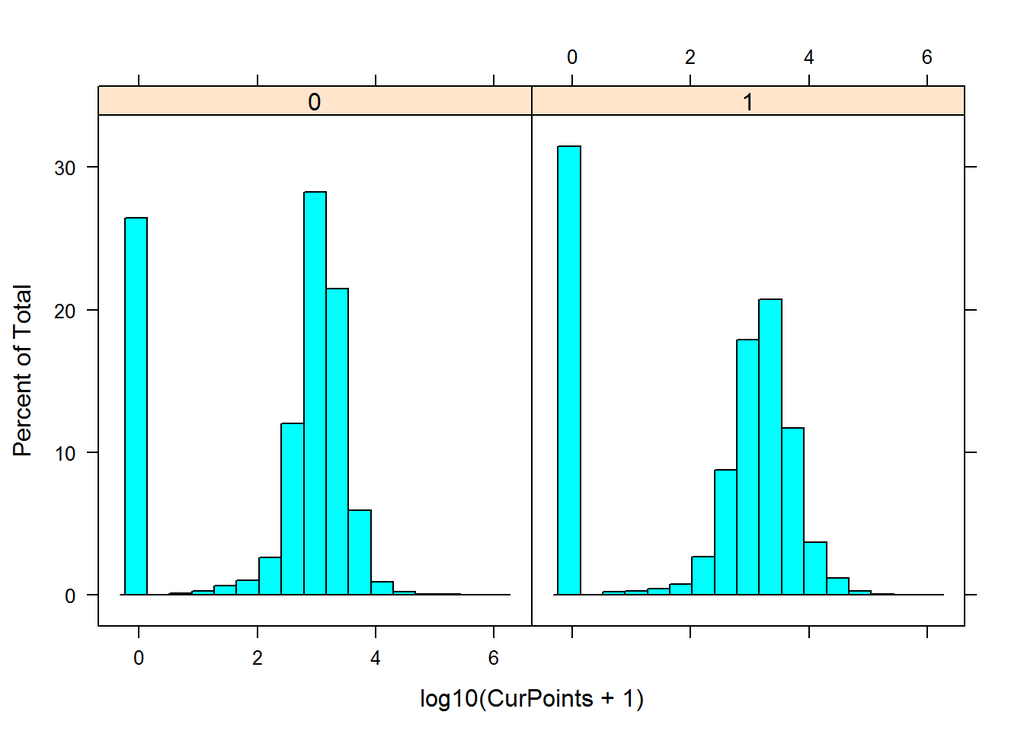

```r
histogram( ~ log10(CurPoints + 1) | result , data = training)
```

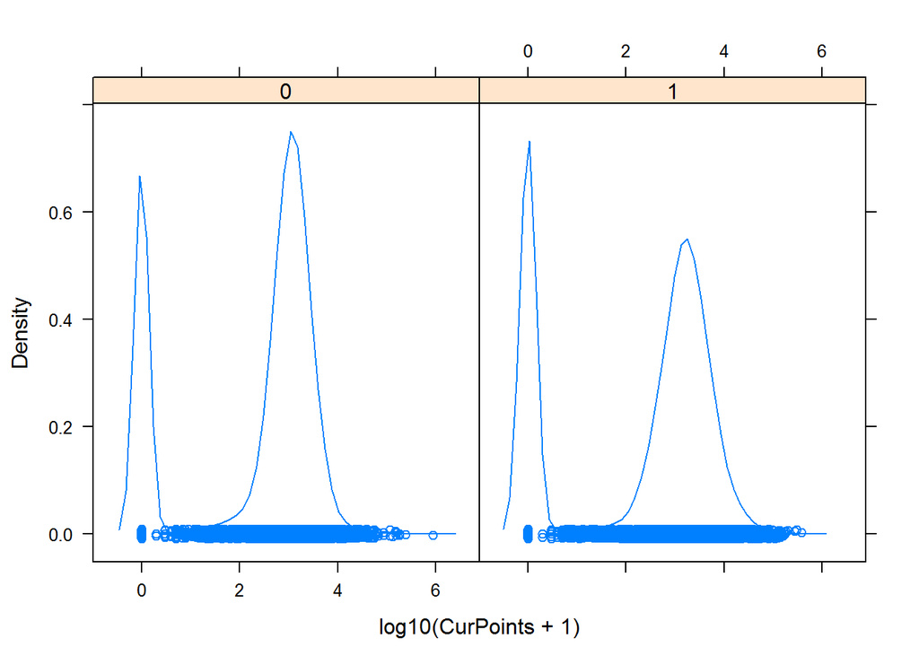

```r
densityplot( ~ log10(CurPoints + 1) | result , data = training)
```

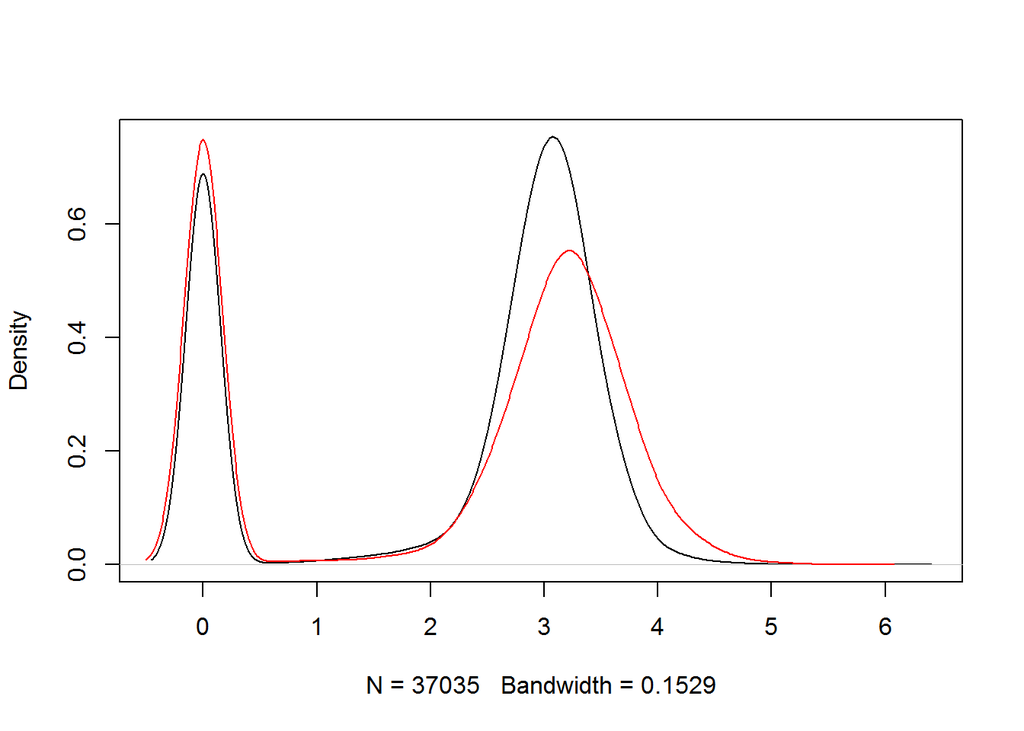

```r
plot(density(log10(training[ training$result == 0 , 'CurPoints'] + 1)) , main = "")
points(density(log10(training[ training$result == 1 , 'CurPoints']+1)) , col = "red" , type = 'l')
```

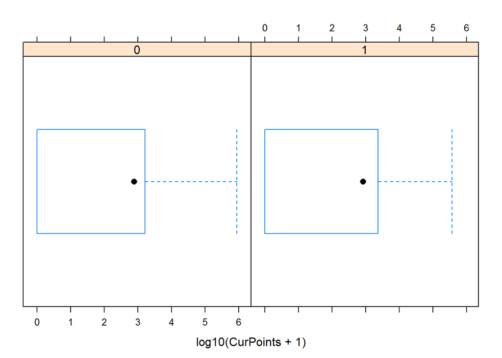

```r
bwplot( ~ log10(CurPoints + 1) | result , data = training)
```

数值检验型

## 检查网龄指标

```r
calcuMissing(training[ , "OnlineId"])
```

```
##   Missing MissingPercentage
## 1       0                 0
```

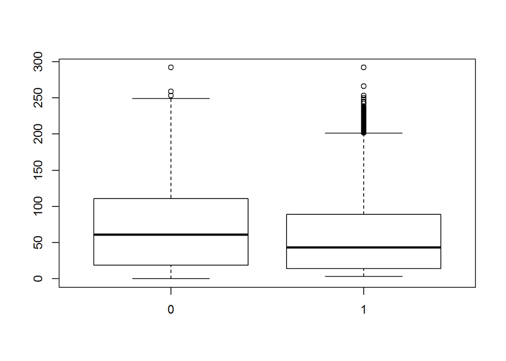

```r
boxplot(training$OnlineId ~ training$result)
```

```r
by(training$OnlineId , training$result , stat.desc)
```

```
## training$result: 0
##      nbr.val     nbr.null       nbr.na          min          max
##    3.704e+04    1.000e+00    0.000e+00    0.000e+00    2.920e+02
##        range          sum       median         mean      SE.mean
##    2.920e+02    2.636e+06    6.100e+01    7.119e+01    2.793e-01
## CI.mean.0.95          var      std.dev     coef.var
##    5.474e-01    2.889e+03    5.375e+01    7.550e-01
## --------------------------------------------------------
## training$result: 1
##      nbr.val     nbr.null       nbr.na          min          max
##    4.044e+04    0.000e+00    0.000e+00    3.000e+00    2.920e+02
##        range          sum       median         mean      SE.mean
##    2.890e+02    2.311e+06    4.300e+01    5.714e+01    2.474e-01
## CI.mean.0.95          var      std.dev     coef.var
##    4.849e-01    2.475e+03    4.975e+01    8.707e-01
```

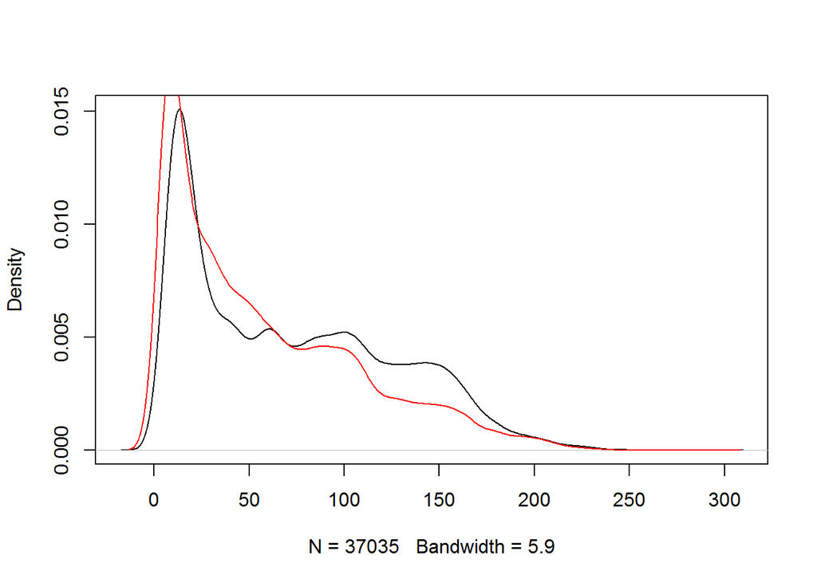

```r
plot(density(training[ training$result == 0 , 'OnlineId']) , main = "")
points(density(training[ training$result == 1 , 'OnlineId']) , col = "red" , type = 'l')
```

```r
uniVarLogistic <- glm(result ~ OnlineId , data = training , family = binomial)
summary(uniVarLogistic)
```

```
##
## Call:
## glm(formula = result ~ OnlineId, family = binomial, data = training)
##
## Deviance Residuals:
##    Min      1Q  Median      3Q     Max
##  -1.36   -1.21    1.01    1.10    1.67
##
## Coefficients:
##              Estimate Std. Error z value Pr(>|z|)
## (Intercept)  0.421601   0.011531    36.6   <2e-16 ***
## OnlineId    -0.005218   0.000141   -37.1   <2e-16 ***
## ---
## Signif. codes:  0 '***' 0.001 '**' 0.01 '*' 0.05 '.' 0.1 ' ' 1
##
## (Dispersion parameter for binomial family taken to be 1)
##
##     Null deviance: 107257  on 77477  degrees of freedom
## Residual deviance: 105850  on 77476  degrees of freedom
## AIC: 105854
##
## Number of Fisher Scoring iterations: 4
```

网龄和是否购买有一定的关系，但这个是一个很弱的预测变量

## 检查年龄指标

```r
calcuMissing(training$UserAge)
```

```
##   Missing MissingPercentage
## 1       0                 0
```

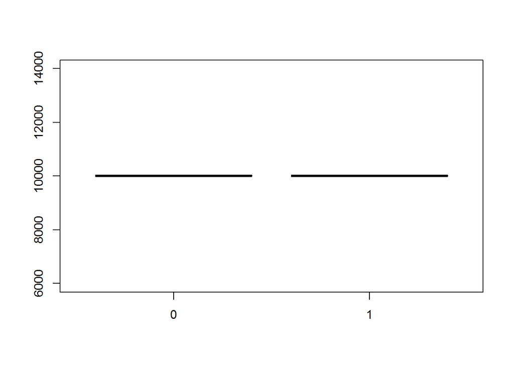

```r
boxplot(training$UserAge ~ training$result)
```

```r
stat.desc(training$UserAge)
```

```
##      nbr.val     nbr.null       nbr.na          min          max
##        77478            0            0         9999         9999
##        range          sum       median         mean      SE.mean
##            0    774702522         9999         9999            0
## CI.mean.0.95          var      std.dev     coef.var
##            0            0            0            0
```

**这个指标没用**

# 3.数据准备

衍生变量如何生成